# Lab 10 Solutions

1. Let’s load the NHL data with cumulative wins information (`nll with cum wins.csv`). Set seed to 364. Create train data set using games before March 15, 2016, and test data set would include data/games after March 15. Thus, we will try to predict a lot more games than we did in the past, 194 to be precise.

```r
library(tidyverse)
library(pROC)
library(descr)
library(caret)
set.seed(364)
nhl2 <- read_csv("nhl with cum wins.csv")
nhl2 <- nhl2 %>% mutate(homewin=as.factor(homewin))
train <- nhl2 %>% filter(Date < as.Date("2016-03-15"))
test <- nhl2 %>% filter(Date >= as.Date("2016-03-15"))
```

2. Estimate a logit model using `cumwins_net` as the only explanatory variable. Is the effect statistically significant? What is the magnitude of the effect?

```r
l1 <- glm(homewin ~ cumwins_net, data=train, family="binomial")
summary(l1)
```

```
##
## Call:
## glm(formula = homewin ~ cumwins_net, family = "binomial", data = train)
##
## Deviance Residuals:
##    Min      1Q  Median      3Q     Max
## -1.457  -1.212   1.010   1.129   1.355
##
## Coefficients:
##             Estimate Std. Error z value Pr(>|z|)
## (Intercept)  0.11424    0.06249   1.828   0.0675 .
## cumwins_net  0.03269    0.01244   2.627   0.0086 **
## ---
## Signif. codes:  0 '***' 0.001 '**' 0.01 '*' 0.05 '.' 0.1 ' ' 1
##
## (Dispersion parameter for binomial family taken to be 1)
##
##     Null deviance: 1433.2  on 1035  degrees of freedom
## Residual deviance: 1426.2  on 1034  degrees of freedom
## AIC: 1430.2
##
## Number of Fisher Scoring iterations: 4
```

```r
exp(coef(l1))
```

```
## (Intercept) cumwins_net
##    1.121024    1.033230
```

`cumwins_net` has a positive and statistically significant effect on the odds of home team winning. The magnitude of the effect is fairly modest though. If net cumulative wins (the difference between cumulative wins of the home minus that of the visiting team) increase by one, the odds of the home team winning go up 3.3%. Put differently, for every additional past win for the home team relative to the visiting team, the odds of home team winning go up by 3.3%.

3. Calculate the probability of the home team winning for every game after and including March 15. The outcome of which two games would you say you are most confident predicting?

```r
test$pred1 <- predict(l1, test, type="response")
test <- arrange(test, pred1)
head(select(test, Date, Visitor, Home, homewin, cumwins_net, pred1), n=2)
```

```
## # A tibble: 2 x 6
##   Date       Visitor             Home                homewin cumwins_net pred1
##   <date>     <chr>               <chr>               <fct>         <dbl> <dbl>
## 1 2016-04-02 Washington Capitals Arizona Coyotes     1               -21 0.361
## 2 2016-03-15 Tampa Bay Lightning Toronto Maple Leafs 1               -17 0.391
```

```r
test <- arrange(test, -pred1)
head(select(test, Date, Visitor, Home, homewin, cumwins_net, pred1), n=2)
```

```
## # A tibble: 2 x 6
##   Date       Visitor               Home                homewin cumwins_net pred1
##   <date>     <chr>                 <chr>               <fct>         <dbl> <dbl>
## 1 2016-03-28 Columbus Blue Jackets Washington Capitals 1                23 0.704
## 2 2016-03-15 Carolina Hurricanes   Washington Capitals 1                18 0.669
```

I am confident about outcomes of games where the probability is close to either 1 or 0. The game between Columbus Blue Jackets and Washington Capitals is the closest to those extremes with 0.7 probability of home team winning (indeed, the home team, Washington, won that game). The second game with probability closest to either 1 or 0 is Carolina vs Washington with probability of 0.67 for home team win (indeed, the home team won again).

4. Make predictions for the outcomes of the games in the test data. Use 0.5 as the cutoff probability for home team winning or losing. Are you happy with the performance of these predictions? What is your Kappa?

```r
test$homewin_pred1 <- as.factor(ifelse(test$pred1 > 0.50, 1, 0))
levels(test$homewin_pred1)
```

```
## [1] "0" "1"
```

```r
crosstab(test$homewin, test$homewin_pred1, prop.t=TRUE, plot=FALSE)
```

```
##    Cell Contents
## |-------------------------|
## |                   Count |
## |           Total Percent |
## |-------------------------|
##
## =====================================
##                 test$homewin_pred1
## test$homewin        0       1   Total
## -------------------------------------
## 0                 36      53      89
##                 18.6%   27.3%
## -------------------------------------
## 1                 30      75     105
##                 15.5%   38.7%
## -------------------------------------
## Total             66     128     194
## =====================================
```

```r
confusionMatrix(test$homewin_pred1, test$homewin)
```

```
## Confusion Matrix and Statistics
##
##           Reference
## Prediction  0  1
##          0 36 30
##          1 53 75
##
##                Accuracy : 0.5722
##                  95% CI : (0.4993, 0.6428)
##     No Information Rate : 0.5412
##     P-Value [Acc > NIR] : 0.21430
##
##                   Kappa : 0.1212
##
##  Mcnemar's Test P-Value : 0.01574
##
##             Sensitivity : 0.4045
##             Specificity : 0.7143
##          Pos Pred Value : 0.5455
##          Neg Pred Value : 0.5859
##              Prevalence : 0.4588
##          Detection Rate : 0.1856
##    Detection Prevalence : 0.3402
##       Balanced Accuracy : 0.5594
##
##        'Positive' Class : 0
##
```

We have 57% accuracy and Kappa of 0.12. This means that the algorithm does better than randomly assigning classes. We do better predicting home wins (specificity=0.71)than predicting home losses (sensitivity=0.4). This is probably because we used a fairly low cutoff for classifying a game as a win leading us to classify many games as home wins.

5. Can you change the probability cutoff and improve on your predictions? Explain your answer.

```r
test$homewin_pred1 <- as.factor(ifelse(test$pred1 > 0.52, "1", "0"))
confusionMatrix(test$homewin_pred1,test$homewin)
```

```
## Confusion Matrix and Statistics
##
##           Reference
## Prediction  0  1
##          0 42 35
##          1 47 70
##
##                Accuracy : 0.5773
##                  95% CI : (0.5045, 0.6477)
##     No Information Rate : 0.5412
##     P-Value [Acc > NIR] : 0.1746
##
##                   Kappa : 0.14
##
##  Mcnemar's Test P-Value : 0.2245
##
##             Sensitivity : 0.4719
##             Specificity : 0.6667
##          Pos Pred Value : 0.5455
##          Neg Pred Value : 0.5983
##              Prevalence : 0.4588
##          Detection Rate : 0.2165
##    Detection Prevalence : 0.3969
##       Balanced Accuracy : 0.5693
##
##        'Positive' Class : 0
##
```

Changing the cutoff will inevitably lead to a different balance between sensitivity and specificity. We may get higher sensitivity but will pay for it with a lower specificity. Kappa is one statistic that summarizes “overall” performance. I experimented and found that a really low cutoff (say 0.4) produces very low Kappa since such low cutoff classifies most games as a home win (we know that only about 52% of games are won by home team). Similarly, setting a really high cutoff (say 0.9) produces very low Kappa since such high cutoff classifies most games as home loss (we know that only about 48% are home losses). A cutoff of 0.52 did slightly better (Kappa of 0.14) than cutoff of 0.5 in the previous question.

6. If `positive` class is that home team loses, what is your sensitivity? What probability cut off would you choose to make sensitivity really high? What will happen to your specificity?

```r
test$homewin_pred1 <- as.factor(ifelse(test$pred1 > 1, 1, 0))
confusionMatrix(test$homewin_pred1,test$homewin)
```

```
## Confusion Matrix and Statistics
##
##           Reference
## Prediction   0   1
##          0  89 105
##          1   0   0
##
##                Accuracy : 0.4588
##                  95% CI : (0.3872, 0.5316)
##     No Information Rate : 0.5412
##     P-Value [Acc > NIR] : 0.9912
##
##                   Kappa : 0
##
##  Mcnemar's Test P-Value : <2e-16
##
##             Sensitivity : 1.0000
##             Specificity : 0.0000
##          Pos Pred Value : 0.4588
##          Neg Pred Value :    NaN
##              Prevalence : 0.4588
##          Detection Rate : 0.4588
##    Detection Prevalence : 1.0000
##       Balanced Accuracy : 0.5000
##
##        'Positive' Class : 0
##
```

Sensitivity is the rate at which we accurately classify the ‘positive’ cases, i.e. home losses. If we want to classify most games are home losses, we need to set a really high cutoff. With a really high cutoff, most games will be classified as home losses. This will mean that the actual home losses will be correctly classified. Our sensitivity will be 1. Of course, our specificity will plummet as all of those home wins are too classfied as home losses.

7. Plot the ROC curve for your logit model with `cumwins_net` as the only predictor.

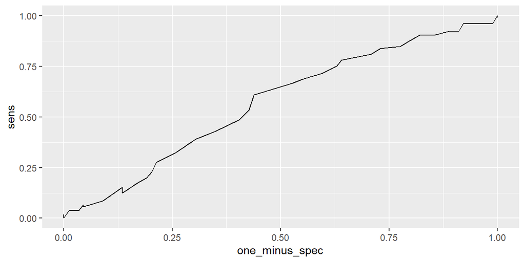

```r
roc <- roc(test$homewin,test$pred1)
#we need to create a data frame that contains the sensitivities and specificities
roc_curves1 <- data.frame(sens=roc$sensitivities,
                        spec=roc$specificities,
                        one_minus_spec=1-roc$spec,
                        model="logit 1")

ggplot(roc_curves1, aes(x=one_minus_spec, y=sens)) + geom_line()
```

```r
auc(roc)
```

```
## Area under the curve: 0.5714
```

8. Estimate an alternative logit model with `cumwins_home` and `cumwins_visit` as the only predictors. Plot the ROC curve for this and the model from question 7. Which model do you prefer, if any?

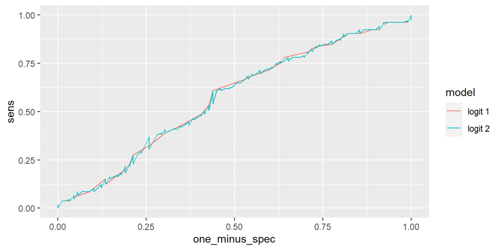

```r
l2 <- glm(homewin ~ cumwins_home+cumwins_visit, data=train, family="binomial")
#summary(l2)
test$pred2 <- predict(l2, test, type="response")
roc <- roc(test$homewin,test$pred2)

roc_curves2 <- data.frame(sens=roc$sensitivities,
                        spec=roc$specificities,
                        one_minus_spec=1-roc$specificities,
                        model="logit 2")
roc_curves <- bind_rows(roc_curves1, roc_curves2)
ggplot(roc_curves, aes(x=one_minus_spec, y=sens, color=model)) + geom_line()
```

```r
auc(roc)
```

```
## Area under the curve: 0.5695
```

The two algorithms seem to perform equally well (or equally poorly, depending on your point of view). Neither algorithm offers a better trade-off between specificity and sensitivity.